# SplicR for the Varmus lab

01

SplicR for the Varmus lab

A549 LKB1 screens, revisited

Sahaj Satani, Pranav Mettu, Ishaan Samantray Cornell students

The paper’s biological question

How does LKB1 restrain lung cancer cell growth in spheroids?

02

The screen points to the PIKFYVE complex. Follow-up experiments connect it to how cells take in growth signals.

SplicR examines the CRISPR evidence behind that story.

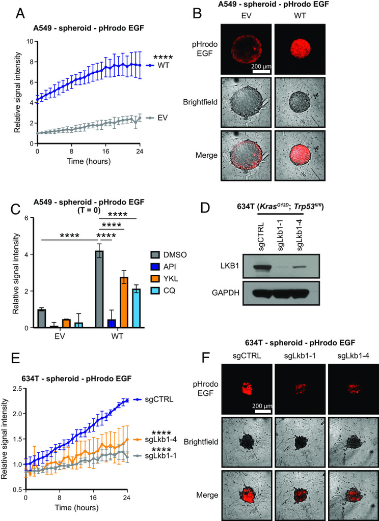

Ferrarone et al., PNAS 2024, Fig. 4. Published experiment, not a SplicR output.

The screen design

A549 cells, TKOv3 knockout library, day 21

03

| Culture | LKB1-null (EV) | LKB1-restored (WT) |
| --- | --- | --- |
| 2D monolayer | a and b | a and b |
| 3D spheroid | a and b | a and b |

One shared plasmid library reference

Eight endpoint samples. The plasmid reference is not a biological replicate.

The deposited files pass identity checks

Both original downloads match Harvard Dataverse V1

04

70,116

observed guides in each table

18,049

genes after guide-ID annotation

104 date-like gene labels corrected per file

Original counts remain unchanged. The analysis uses TKOv3 annotations keyed by guide ID.

Upload the original count tables

05

Two files. No FASTQ download is needed for this count-table demo.

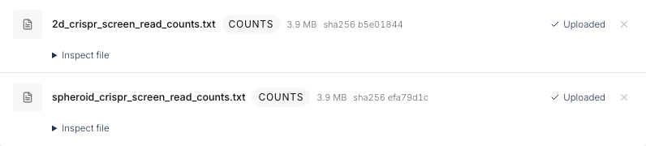

SplicR identifies the guide library

06

All observed guide IDs match TKOv3. The mapping stays visible for review.

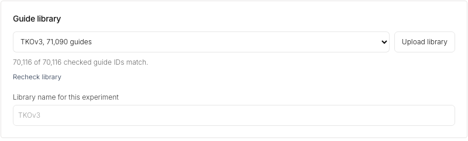

Six comparisons, ready to review

07

EV versus plasmid. WT versus plasmid. WT versus EV. Separately for each culture.

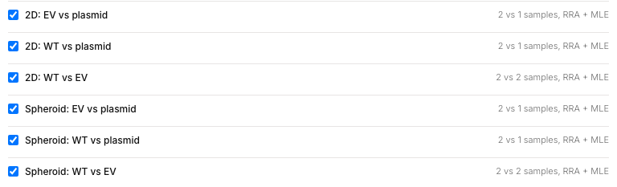

Researchers control the analysis

08

Median normalization. FDR threshold 0.05. RRA with optional MLE. The reviewed plan travels with the run.

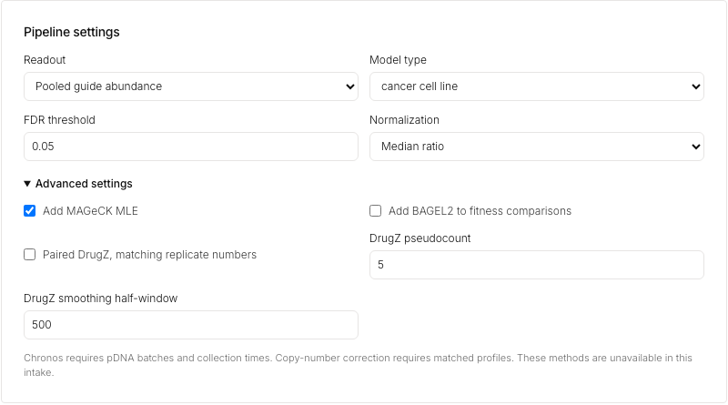

Live progress follows recorded stages

09

All six full RRA + MLE analyses are complete.

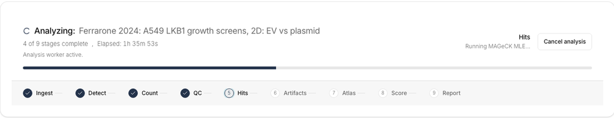

Captured during MLE fitting. All six full RRA + MLE analyses are now complete.

A completed report exposes uncertainty

Spheroid WT versus plasmid, completed RRA + MLE run

10

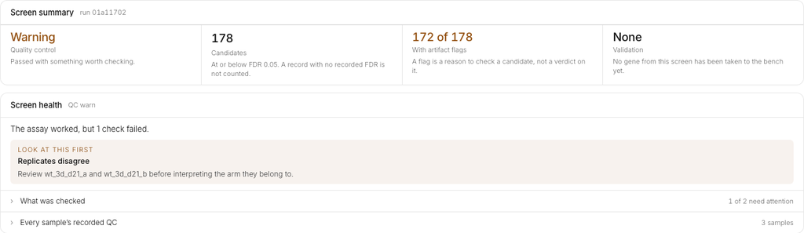

178 candidates. 172 flagged for review, not automatic rejection.

176 depleted. 154 annotated pan-essential in DepMap, consistent with common survival dependencies.

Results across the six comparisons

RRA candidates at the declared two-direction FDR threshold of 0.05

11

Spheroid WT / EV

0

Spheroid WT / plasmid

178

Spheroid EV / plasmid

159

2D WT / EV

0

2D WT / plasmid

271

2D EV / plasmid

205

Each report covers 18,049 genes. These RRA counts do not reproduce the paper’s MLE figure.

The paper’s genes, across both methods

Spheroid WT versus plasmid, complete recorded output

12

| Gene | RRA log₂ change | MLE beta | MLE FDR |
| --- | --- | --- | --- |
| FIG4 | +3.14 | +1.83 | 0.576 |
| VAC14 | +4.96 | +3.21 | 0.192 |
| PIKFYVE | +0.41 | +0.44 | 1.000 |

Positive effects and significance are different questions

None passes MLE FDR 0.05 here. The paper’s beta-score nomination uses different criteria.

The export keeps the underlying evidence

CSV for analysis. JSON and receipts for reproducibility.

13

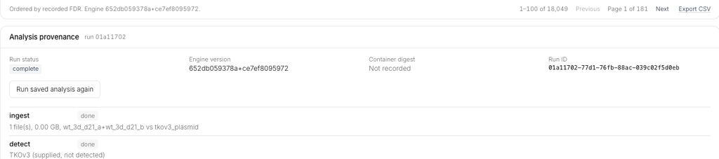

18,049 gene rows per comparison Inputs, settings and quality warnings remain attached to the run.

The demo includes the actual downloaded CSV and complete receipts for all six RRA + MLE runs.

Measured runtime and reproducibility

Completed RRA batch, original deposited count tables

14

6 min 2 sec

First worker start to last worker finish across six comparisons

97–126 sec per worker

Local and cloud primary statistics agree exactly

RRA timing shown. Initial full MLE cohort: 5 h 5 min, including retries. Upload time excluded.

SplicR alongside Broad Apron

Apron already offers a strong guided analysis workflow

15

| This study | Broad Apron guide | SplicR demonstration |
| --- | --- | --- |
| Starting files | PoolQ counts and annotations Other inputs need formatting | Original deposited count tables |
| Design setup | User defines references and data configurations | Six editable suggestions from verified source identity |
| Gene statistics | Control-set z-scores and empirical null | MAGeCK RRA Optional separate MLE |
| Annotations and evidence | Guide describes QC and analysis exports | Guide-ID annotation repair Flags beside recorded results |

Documented workflow comparison. No head-to-head accuracy or runtime benchmark.

Other tools and SplicR’s role

Established methods remain the statistical foundation

16

| Tool | Established strength | SplicR’s role in this demo |
| --- | --- | --- |
| MAGeCK | RRA and MLE Explicit experimental designs | Guided setup, hosted compute and reviewable reports |
| PinAPL-Py | Web analysis, custom libraries Automated read extraction | Shared workspace context and source-linked run receipts |
| Broad Apron | Guided QC and control-set gene aggregation | Verified study intake and guide-ID annotation repair |

SplicR has no demonstrated universal accuracy advantage over these methods.

A reusable workflow for other labs

17

Researchers can change sample roles, replicates and factors. Their experiment determines the configuration.

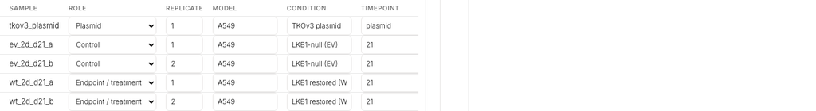

A pilot with the Varmus lab

18

A reproducible starting point for the next screen

Agree on the reference analysis. Review differences together. Test candidate genes in the lab.

Sahaj Satani, Pranav Mettu, Ishaan Samantray

Methods and scientific limits

Appendix for scientific discussion

19

Completed evidence

Original counts and verified guide annotations Six RRA + MLE reports with separate statistics Independent RRA numerical reproduction

Open scientific work

Reconcile MLE with the authors’ settings Fit a formal culture interaction if required Validate candidates experimentally

Validation probabilities remain unavailable without a fitted outcomes cohort.

Sources and demo files

Appendix for follow-up

20

Paper 10.1073/pnas.2403685121 CRISPR data 10.7910/DVN/8DEPIT

SplicR-Ferrarone-demo.zip Two original count tables SplicR-Ferrarone-full-results.zip Six complete RRA + MLE result packages

[Open full spheroid WT report](https://www.splicr.org/dashboard/screens/01a11702-77cc-72e2-9307-ab884d26facb)

Report requires sign-in to the retained demo workspace. All six full RRA + MLE packages are included.